# Project: Investigate a Dataset (Replace this with something more specific!)

## Exploratory Data Analysis

### Research Question 1 (Do popular movies have a higher vote_average? Is there a correlation between a movie's rating and its popularity?)

#### Part1: Build a dataset that consist of vote_average and popularity

```python
rating_popularity = df.loc[:,['original_title','popularity','vote_average']]
rating_popularity.head()
```

|  | original_title | popularity | vote_average |
| --- | --- | --- | --- |
| 0 | Jurassic World | 32.985763 | 6.5 |
| 1 | Mad Max: Fury Road | 28.419936 | 7.1 |
| 2 | Insurgent | 13.112507 | 6.3 |
| 3 | Star Wars: The Force Awakens | 11.173104 | 7.5 |
| 4 | Furious 7 | 9.335014 | 7.3 |

Save this file:

```python
rating_popularity.to_csv('rating_popularity.csv', index = False)
```

Lets visualize to see if there are any correlations:

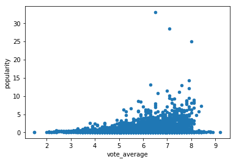

```python
# Create a plot to visualize:

rating_popularity.plot(x='vote_average', y='popularity', kind = 'scatter');
```

From the visualization above, we cannot see any obvious correlations.

#### Part2: Extract the 200 highest rated movies to see if there are any correlations

```python
rating_popularity.sort_values(by=['vote_average'], ascending = False).head(200)
```

|  | original_title | popularity | vote_average |
| --- | --- | --- | --- |
| 3894 | The Story of Film: An Odyssey | 0.006925 | 9.2 |
| 538 | The Mask You Live In | 0.114264 | 8.9 |
| 2269 | Life Cycles | 0.222293 | 8.8 |
| 1200 | Black Mirror: White Christmas | 0.129531 | 8.8 |
| 6911 | Pink Floyd: Pulse | 0.212010 | 8.7 |
| 2401 | Opeth: In Live Concert At The Royal Albert Hall | 0.067753 | 8.6 |
| 3690 | The Art of Flight | 0.321341 | 8.5 |
| 8411 | Queen - Rock Montreal | 0.302908 | 8.5 |
| 8221 | A Personal Journey with Martin Scorsese Throug... | 0.194889 | 8.5 |
| 5830 | Doctor Who: The Time of the Doctor | 0.248944 | 8.5 |
| 8839 | Dave Chappelle: Killin' Them Softly | 0.157001 | 8.5 |
| 3224 | John Mayer: Where the Light Is Live in Los Ang... | 0.224721 | 8.5 |
| 9290 | Depeche Mode: 101 | 0.260602 | 8.4 |
| 5923 | Tropico | 0.107333 | 8.4 |
| 7948 | Stop Making Sense | 0.283191 | 8.4 |
| 2334 | Rush: Beyond the Lighted Stage | 0.145026 | 8.4 |
| 8370 | Bill Hicks: Relentless | 0.035384 | 8.4 |
| 4178 | The Shawshank Redemption | 7.192039 | 8.4 |
| 2397 | The Making of The Walking Dead | 0.033048 | 8.4 |
| 609 | The Jinx: The Life and Deaths of Robert Durst | 0.033378 | 8.4 |
| 3365 | Foo Fighters: Live at Wembley Stadium | 0.002475 | 8.4 |
| 5986 | Guten Tag, RamÃ³n | 0.054380 | 8.4 |
| 4164 | The Century of the Self | 0.090605 | 8.3 |
| 7269 | The Godfather | 5.738034 | 8.3 |
| 6549 | The Devil and Daniel Johnston | 0.021811 | 8.3 |
| 1322 | One Direction: Where We Are - The Concert | 0.004853 | 8.3 |
| 4547 | London 2012 Olympic Opening Ceremony: Isles of... | 0.520520 | 8.3 |
| 2313 | Tick Tock Tale | 0.172275 | 8.3 |
| 6176 | Shoah | 0.147489 | 8.3 |
| 4803 | One Direction: Up All Night - The Live Tour | 0.162227 | 8.3 |
| ... | ... | ... | ... |
| 3911 | The Lord of the Rings: The Two Towers | 8.095275 | 7.8 |
| 694 | The Fault in Our Stars | 2.293859 | 7.8 |
| 4797 | Doctor Who: The Snowmen | 0.167501 | 7.8 |
| 3846 | Undefeated | 0.122543 | 7.8 |
| 3814 | Jiro Dreams of Sushi | 0.167149 | 7.8 |
| 3110 | Jodhaa Akbar | 0.389554 | 7.8 |
| 669 | The Theory of Everything | 3.170271 | 7.8 |
| 28 | Spotlight | 4.062293 | 7.8 |
| 3182 | Chris Rock: Kill the Messenger | 0.279806 | 7.8 |
| 635 | Big Hero 6 | 8.691294 | 7.8 |
| 3254 | Front of the Class | 0.173639 | 7.8 |
| 587 | The Hunting Ground | 0.062536 | 7.8 |
| 578 | Requiem for the American Dream | 0.080754 | 7.8 |
| 1177 | JohnnyExpress | 0.153047 | 7.8 |
| 6067 | Beyonce: Life Is But A Dream | 0.008540 | 7.8 |
| 390 | An Inspector Calls | 0.309811 | 7.8 |
| 8316 | The Power of One | 0.348536 | 7.8 |
| 1217 | Over the Garden Wall | 0.107621 | 7.8 |
| 10173 | Taxi Driver | 2.582657 | 7.8 |
| 1438 | Mr. Nobody | 1.260010 | 7.8 |
| 7988 | Scarface | 3.178818 | 7.8 |
| 8173 | Pride and Prejudice | 0.399720 | 7.8 |
| 1267 | Wanderers | 0.045010 | 7.8 |
| 7987 | Return of the Jedi | 4.828854 | 7.8 |
| 2633 | The Lord of the Rings: The Fellowship of the Ring | 8.575419 | 7.8 |
| 1486 | 3 Idiots | 0.816681 | 7.8 |
| 2553 | The Best Man | 0.066504 | 7.8 |
| 1513 | Home | 0.688361 | 7.8 |
| 5311 | Geri's Game | 0.559337 | 7.8 |
| 2130 | Dog Pound | 0.478118 | 7.7 |

200 rows × 3 columns

```python
# Save the results to a variable.

top_200 = rating_popularity.sort_values(by=['vote_average'], ascending = False).head(200)
```

Let's save this to a csv:

```python
top_200.to_csv('top_200.csv', index = False)
```

Let's visualize this:

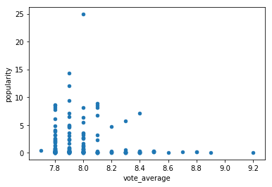

```python
top_200.plot(x='vote_average', y='popularity', kind = 'scatter');
```

From this visualization, a correlation between popularity and rating is still not able to be determined. More investigation is still needed.

#### Part3: Extract the 200 lowest rated movies to see if there are any correlations

```python
rating_popularity.sort_values(by=['vote_average'], ascending = True).head(200)
```

|  | original_title | popularity | vote_average |
| --- | --- | --- | --- |
| 10865 | Manos: The Hands of Fate | 0.035919 | 1.5 |
| 7772 | Transmorphers | 0.121120 | 1.5 |
| 4882 | Jurassic Shark | 0.079281 | 2.0 |
| 3822 | Sand Sharks | 0.159707 | 2.1 |
| 7220 | Superbabies: Baby Geniuses 2 | 0.157959 | 2.1 |
| 2373 | Birdemic: Shock and Terror | 0.150035 | 2.1 |
| 4859 | Foodfight! | 0.111351 | 2.2 |
| 4910 | The Sleeper | 0.041297 | 2.2 |
| 6077 | Atlantic Rim | 0.002648 | 2.2 |
| 7235 | Dracula 3000 | 0.209701 | 2.3 |
| 9291 | Going Overboard | 0.153473 | 2.3 |
| 2298 | Slow Torture Puke Chamber | 0.194905 | 2.4 |
| 2280 | Mega Shark vs. Crocosaurus | 0.211508 | 2.4 |
| 5960 | The Contractor | 0.134357 | 2.4 |
| 1205 | Jersey Shore Massacre | 0.118137 | 2.4 |
| 1072 | Age of Tomorrow | 0.634232 | 2.4 |
| 4793 | American Warships | 0.173159 | 2.4 |
| 546 | The Ouija Experiment 2: Theatre of Death | 0.138559 | 2.4 |
| 2258 | 2010: Moby Dick | 0.234574 | 2.5 |
| 6404 | All About Anna | 0.327022 | 2.5 |
| 3132 | 2012 Doomsday | 0.348223 | 2.6 |
| 452 | Robert the Doll | 0.212872 | 2.6 |
| 5663 | 30 Nights of Paranormal Activity With the Devi... | 0.473599 | 2.6 |
| 8062 | Metalstorm: The Destruction of Jared-Syn | 0.085136 | 2.7 |
| 2278 | Cheerleader Camp | 0.213623 | 2.7 |
| 2157 | Titanic II | 0.407787 | 2.7 |
| 6915 | Pledge This! | 0.095207 | 2.8 |
| 9650 | Surf Nazis Must Die | 0.359238 | 2.8 |
| 2325 | Mega Piranha | 0.157333 | 2.8 |
| 5933 | Hansel & Gretel: Warriors of Witchcraft | 0.109305 | 2.8 |
| ... | ... | ... | ... |
| 4694 | Storage 24 | 0.287294 | 3.6 |
| 4819 | Donner Pass | 0.146925 | 3.6 |
| 2153 | BloodRayne: The Third Reich | 0.417035 | 3.6 |
| 4869 | Scary or Die | 0.092594 | 3.6 |
| 4804 | 40 Days and Nights | 0.162030 | 3.6 |
| 1056 | Authors Anonymous | 0.269033 | 3.7 |
| 1178 | Sharktopus vs Pteracuda | 0.151929 | 3.7 |
| 6476 | Carlito's Way: Rise to Power | 0.182135 | 3.7 |
| 326 | San Andreas Quake | 0.369108 | 3.7 |
| 9149 | Tale of the Mummy | 0.175128 | 3.7 |
| 2855 | Down | 0.128169 | 3.7 |
| 9603 | Jaws: The Revenge | 1.285867 | 3.7 |
| 5818 | 100 Degrees Below Zero | 0.265782 | 3.7 |
| 4621 | Outpost: Black Sun | 0.386979 | 3.7 |
| 1846 | Paintball | 0.123497 | 3.7 |
| 8230 | Darkman II: The Return of Durant | 0.141372 | 3.7 |
| 3343 | Flirting with Forty | 0.060669 | 3.7 |
| 8585 | Kazaam | 0.369040 | 3.7 |
| 1739 | Transylmania | 0.270283 | 3.7 |
| 400 | Condemned | 0.272995 | 3.7 |
| 4868 | Among Friends | 0.096174 | 3.7 |
| 1773 | ZMD: Zombies of Mass Destruction | 0.428574 | 3.7 |
| 3712 | Doomsday Prophecy | 0.292536 | 3.7 |
| 2282 | Riverworld | 0.210425 | 3.7 |
| 1127 | The Redwood Massacre | 0.161001 | 3.8 |
| 558 | Anguish | 0.097790 | 3.8 |
| 2611 | Baby Geniuses | 0.116694 | 3.8 |
| 8209 | Jury Duty | 0.269228 | 3.8 |
| 7651 | Blonde Ambition | 0.296790 | 3.8 |
| 7482 | I Know Who Killed Me | 0.811539 | 3.8 |

200 rows × 3 columns

Save the result to a variable:

```python
# Save the results to a variable.

bot_200 = rating_popularity.sort_values(by=['vote_average'], ascending = True).head(200)
```

Let's save this to a csv:

```python
bot_200.to_csv('bot_200.csv', index = False)
```

Let's visual this:

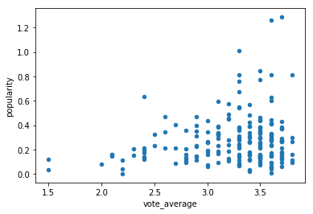

```python
bot_200.plot(x='vote_average', y='popularity', kind = 'scatter');
```

In the bottom 200 data points, there is some correlation in the right hand side. However, this is not enough evidence to indicate a correlation between the two variables.

#### Part 4: Correlation coefficient computation

```python
# Lets use .corr to compute the correlation coefficient between the two variables:
rating_popularity['popularity'].corr(rating_popularity['vote_average'])
```

```
0.20951130747540375
```

As the number 0.2095 suggests, there is no direct indication of correlation between two variables.

#### Part 5: Conclusion

There isn't enough evidences to show a correlation between the variable in this investigation. From what is given, rating and popularity isn't correlated in the case of movies.

#### Part 6: Limitations

Three scatter plots have their limitations in showing the mutiple sets of values together. The dots becomes too many and it may distract one from doing proper analysis. As of the correlation coefficient, only Pearson's was used. Other computation methods such as Kendall's were not used in this part of the analysis.

#### Part 1: Getting profit for all movies

```python
df['profit'] = df['revenue'] - df['budget']
df.head()
```

[output not shown]

5 rows × 23 columns

#### Part 2: Getting profit_adj for all movies

```python
df['profit_adj'] = df['revenue_adj'] - df['budget_adj']
df.head()
```

[output not shown]

#### Part 3: highest 10 by profit

```python
df.sort_values(by=['profit'], ascending = False).head(10)
```

[output not shown]

10 rows × 23 columns

The top 10 are: Avatar, Star Wars: The Force Awakens, Titanic, Jurassic World, Furious 7, The Avengers, Harry Potter and the Deathly Hallows: Part 2, Avengers: Age of Ultron, Frozen, and The Net

#### Part 4: sort by profit_adj

```python
df.sort_values(by=['profit_adj'], ascending = False).head(10)
```

[output not shown]

10 rows × 23 columns

The top 10 are: Star Wars, Avatar, Titanic, The Exorcist, Jaws, E.T. the Extra-Terrestrial, Star Wars: The Force Awaken, The Net, One Hundred and One Dalmatians, and The Empire Strikes Back

#### Part 6: Limitations

We don't know how the adjusted values are determined, so we cannot compare the adjusted with the unadjusted.

### References:

https://github.com/allanbreyes/udacity-data-science/tree/master/p1